# Maternal At Birth → Cord Blood: Selective Transplacental Transfer

Paired within-pair change (maternal at birth → cord blood) — missing data structure, transfer direction, and per-antigen / per-analyte distributions

Scot Zens

2026-06-30

# The Question

Maternal antibody **at birth/delivery** is compared with **cord blood** to characterise **transplacental transfer**. Transfer is FcRn-mediated and **selective**: efficiency varies by IgG subclass (IgG1 transfers most efficiently; IgG2 least) and by antigen, and cord levels can exceed maternal levels for some specificities (active concentration) while falling short for others. Direction is therefore **not uniform** and is the object of interest here.

**Convention:** delta = log10 value in **cord blood** − log10 value at **maternal birth**. Positive delta = cord exceeds maternal (relative enrichment / efficient transfer); negative delta = cord below maternal (less efficient transfer).

# Data and Coverage

Features with at least one paired subject: **39**; with ≥ 10 paired: **38**.

Table 1. Per-feature coverage: subjects with MatBirth, with CordBlood, and with BOTH (the n used). Features with n paired = 0 were not measured at one visit and are excluded from all change analyses.

| Feature | n MatBirth | n CordBlood | n paired (both) |
| --- | --- | --- | --- |
| DT_IgG | 283 | 287 | 283 |
| FHA_IgG | 283 | 287 | 283 |
| FIM_IgG | 283 | 287 | 283 |
| PRN_IgG | 283 | 287 | 283 |
| PT_IgG | 283 | 287 | 283 |
| TT_IgG | 283 | 287 | 283 |
| DT_IgG1 | 247 | 242 | 240 |
| DT_IgG4 | 247 | 242 | 240 |
| FHA_IgG1 | 247 | 242 | 240 |
| FHA_IgG4 | 247 | 242 | 240 |
| IPV1_IgG1 | 247 | 242 | 240 |
| IPV1_IgG4 | 247 | 242 | 240 |
| IPV2_IgG1 | 247 | 242 | 240 |
| IPV2_IgG4 | 247 | 242 | 240 |
| IPV3_IgG1 | 247 | 242 | 240 |
| IPV3_IgG4 | 247 | 242 | 240 |
| PRN_IgG1 | 247 | 242 | 240 |
| PRN_IgG4 | 247 | 242 | 240 |
| PT_IgG1 | 247 | 242 | 240 |
| PT_IgG4 | 247 | 242 | 240 |
| TT_IgG1 | 247 | 242 | 240 |
| TT_IgG4 | 247 | 242 | 240 |
| DT_IgG3 | 241 | 236 | 234 |
| FHA_IgG3 | 241 | 236 | 234 |
| IPV1_IgG3 | 241 | 236 | 234 |
| IPV2_IgG3 | 241 | 236 | 234 |
| IPV3_IgG3 | 241 | 236 | 234 |
| PRN_IgG3 | 241 | 236 | 234 |
| PT_IgG3 | 241 | 236 | 234 |
| TT_IgG3 | 241 | 236 | 234 |
| DT_IgG2 | 235 | 225 | 223 |
| FHA_IgG2 | 235 | 225 | 223 |
| PRN_IgG2 | 235 | 225 | 223 |
| PT_IgG2 | 235 | 225 | 223 |
| TT_IgG2 | 235 | 225 | 223 |
| IPV1_IgG2 | 217 | 208 | 206 |
| IPV2_IgG2 | 217 | 208 | 206 |
| IPV3_IgG2 | 217 | 208 | 206 |
| WHOLE_WT_IgG | 0 | 209 | 0 |

# Missing Data: Sources, Structure, and Implications

Not all subjects contribute equally to every feature’s paired analysis, and the reasons differ in important ways. Understanding the missing-data structure is essential before interpreting the change estimates: subjects who are missing at one or both visits may differ systematically from those with complete data, and the pattern of missingness itself reveals aspects of the assay design that affect what questions can be answered.

## Why paired counts differ across features

There are four distinct sources of missingness in this dataset, each with a different cause and a different implication for bias:

**Type A — Analyte never assayed at one visit (structural panel gap).** Some analytes may not have been run at one of the two visits at all, giving n = 0 there. This is a design decision, not subject dropout, and is **not correctable** from the existing data: no paired change can be computed for those analytes. (See Table 1 for which features have n paired = 0.)

**Type B — One visit’s panel run on a smaller sub-cohort than the other.** For features measured at both visits, the number of observations at the two visits can differ if a panel was rolled out to different subject batches. The per-analyte step-down below shows the structure:

Table 2. Per-analyte-group sample sizes at the earlier (MatBirth) and later (CordBlood) visit. Each row is a set of features sharing the same coverage. The gap (CordBlood minus MatBirth) quantifies subjects present at the later visit but not the earlier one for that analyte group — subjects who cannot contribute to any paired change analysis for those features.

| Analyte group | N features | Typical n MatBirth | Typical n CordBlood | Typical n paired | CordBlood minus MatBirth |
| --- | --- | --- | --- | --- | --- |
| Total IgG (antigen-specific) | 6 | 283 | 287 | 283 | 4 |
| IgG1 and IgG4 | 16 | 247 | 242 | 240 | -5 |
| IgG3 | 8 | 241 | 236 | 234 | -5 |
| IgG2 — core antigens | 5 | 235 | 225 | 223 | -10 |
| IgG2 — IPV antigens | 3 | 217 | 208 | 206 | -9 |

Any stepped structure here reflects which analyte panels were run on which subject batches, rather than subject dropout. Where one analyte is available on fewer subjects than another, the smaller subset may differ systematically (e.g. earlier-enrolled or a specific plate batch); confirm before pooling those features with the better-covered ones. *Specifics to be read from the rendered Table 2.*

**Type C — Dropout (subjects with a value at one visit but not the other).** Subjects present at one visit but missing the other contribute to that visit’s cross-sectional n but not to the paired change. The size of this group is the gap between each visit’s n and the paired n in Table 1.

**Type D — Feature-level NA within otherwise assayed subjects.** A subject may attend both visits yet still be dropped from a feature’s paired analysis if the value failed QC at one visit (insufficient volume, assay failure). This is the difference between the per-visit n and the paired n not explained by Type B/C.

## Visualising missingness structure

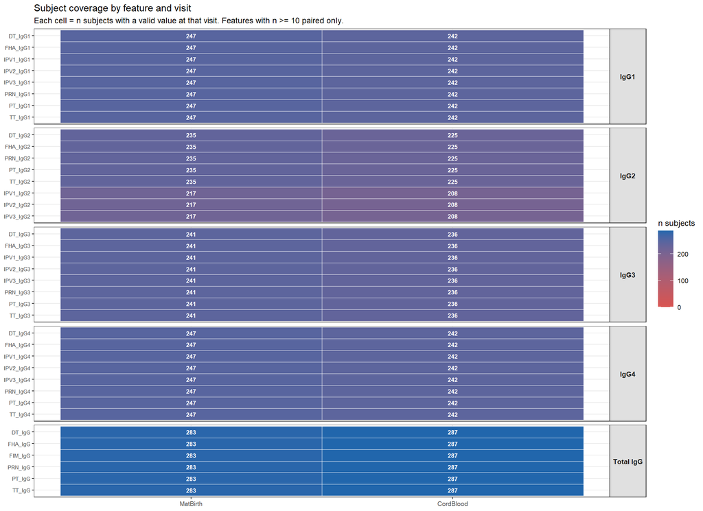

Figure M1. Coverage heatmap: number of subjects with a valid measurement at the earlier and later visit for every well-covered feature (n >= 10 paired). Features are grouped by analyte type and ordered by earlier-visit n within group. Any step-down in coverage by analyte group (Type B missingness) is visible here.

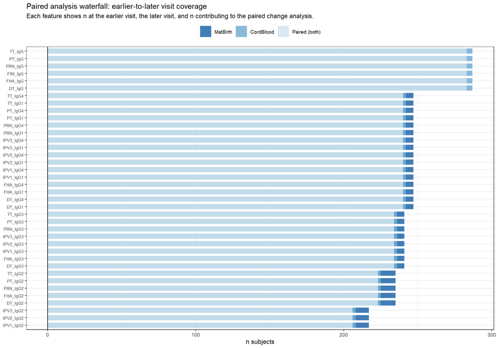

Figure M2. Paired analysis waterfall: for each well-covered feature, overlapping bars show n subjects at the earlier visit (dark blue), at the later visit (medium blue), and paired at both (light blue). The gap between the later-visit bar and the paired bar is Type B+C+D missingness. Features ordered by n paired.

## Subject-level missingness patterns

The per-feature view above (Figures M1–M2) is computed from the coverage summary. To see missingness *at the subject level* we use the paired dataset directly: each subject contributes a known set of features to the paired change analysis, and the **number of features a subject contributes** reveals which assay batches they were part of. A subject who received the full panel contributes up to 10+ features; a subject in an early, total-IgG-only batch contributes far fewer.

One limitation to state plainly: the paired dataset contains only subjects who achieved **at least one** valid earlier↔︎later visit pairing. Subjects who attended only one visit, or whose every measurement failed pairing, do not appear here at all — quantifying that group requires the per-visit raw records and is not attempted in this document. The per-feature coverage gaps in Table 1 (e.g. later-visit n exceeding earlier-visit n) are the aggregate footprint of those subjects.

Table 3. Number of subjects contributing at least one paired feature to each analyte group. Derived from the paired dataset only. The drop from Total IgG down through the subclasses mirrors any earlier-visit assay batch step-down in Table 2: fewer subjects had cord-blood subclass panels run, so fewer can contribute paired subclass features.

| Analyte group | N subjects contributing ≥ 1 paired feature |
| --- | --- |
| Total IgG | 283 |
| IgG1 | 240 |
| IgG4 | 240 |
| IgG3 | 234 |
| IgG2 | 223 |

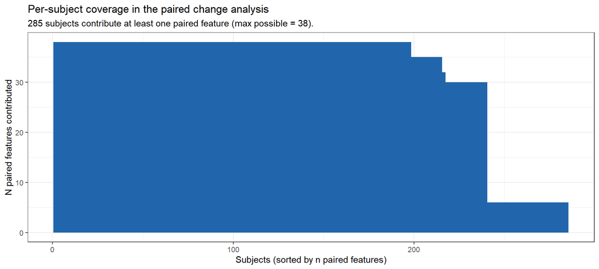

Figure M3. Per-subject paired-feature coverage. Each bar is one subject; height = number of distinct features that subject contributes to the paired change analysis, sorted descending. The flat plateaus reflect the assay batch structure: subjects either received a given panel or did not, producing discrete coverage levels rather than a smooth gradient.

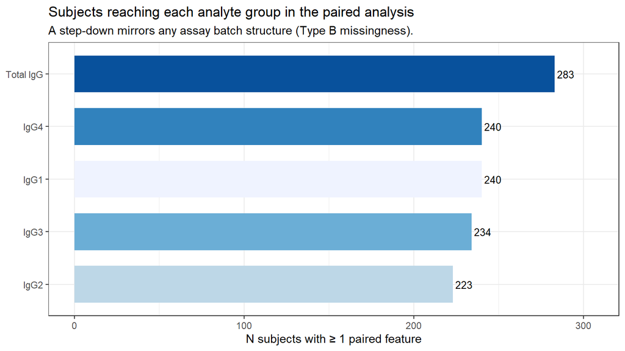

Figure M4. Number of subjects contributing at least one paired feature, by analyte group. The step-down from Total IgG through the IgG subclasses is the subject-level signature of any assay batch rollout (Type B missingness): if a panel was run on fewer samples at one visit, progressively fewer subjects can contribute that paired feature.

## Implications of the missingness structure for change estimates

*Brief notes — to be expanded after reviewing the rendered tables and figures.*

- **Batch / sub-cohort structure (Table 2, Figures M1–M4).** If different analytes were run on different subject batches, the subjects contributing to one analyte’s paired analysis may not be the same population as another’s; check before pooling across analytes.
- **Paired loss with both visits present (Type D).** Subjects with both visit records but a missing paired value warrant a look: do they cluster by site, collection date, or maternal arm, and do their available single-visit values differ from the paired group?
- **Per-visit-only subjects (Type C).** These inflate the cross-sectional n at one visit relative to what is available for the paired change analysis.

# Direction of Change Across All Features

- Across the **38** well-covered features, **13** are *mostly increasing*, **21** are *mostly decreasing*, and **4** are *mixed* (no clear net direction).
- Pooling all subject×feature observations, **46.0%** show an increase (median delta = **+0.000** log10).
- Of the **6** total-antigen IgG features, **6** are *mostly increasing*.
- Per subject (mean delta across all their features), **58.2%** have a net positive shift (median per-subject offset = **+0.022** log10).
- Analytes with **zero observations at one or both visits** cannot contribute to this change analysis (see Table 1).

> **Verdict:** The change splits **by IgG subclass, not by antigen**: 13 features increase, 21 decrease, 4 mixed. Analytes transferred above maternal (cord > maternal): IgG1, IgG; transferred below maternal: IgG3, IgG2, IgG4 — the hierarchy of selective, FcRn-mediated transplacental transfer, in which the best-transferred subclass is actively concentrated in the fetal circulation. The per-arm split is in Tables 7-8 and Figure A1; see also the per-analyte (Table 5), per-antigen (Table 6) breakdowns and the Interpretation section below.

Table 4. Per-feature paired change (later vs earlier visit), sorted by % increasing. Positive delta = increase.

| feature | class | antigen | analyte | n_paired | % increase | % decrease | median delta | mean delta | p signed-rank | p sign-test | direction |
| --- | --- | --- | --- | --- | --- | --- | --- | --- | --- | --- | --- |
| TT_IgG | Total IgG | TT | IgG | 283 | 79.2 | 20.8 | 0.107 | 0.099 | 0.00e+00 | 0.00e+00 | mostly increase |
| TT_IgG1 | IgG subclass | TT | IgG1 | 240 | 76.2 | 23.8 | 0.071 | 0.063 | 0.00e+00 | 0.00e+00 | mostly increase |
| PT_IgG | Total IgG | PT | IgG | 283 | 75.6 | 24.4 | 0.092 | 0.085 | 0.00e+00 | 0.00e+00 | mostly increase |
| FHA_IgG | Total IgG | FHA | IgG | 283 | 73.9 | 26.1 | 0.099 | 0.084 | 0.00e+00 | 0.00e+00 | mostly increase |
| DT_IgG1 | IgG subclass | DT | IgG1 | 240 | 73.3 | 26.2 | 0.081 | 0.061 | 0.00e+00 | 0.00e+00 | mostly increase |
| FHA_IgG1 | IgG subclass | FHA | IgG1 | 240 | 70.8 | 28.8 | 0.113 | 0.102 | 0.00e+00 | 0.00e+00 | mostly increase |
| IPV2_IgG1 | IgG subclass | IPV2 | IgG1 | 240 | 69.6 | 29.6 | 0.063 | 0.051 | 0.00e+00 | 0.00e+00 | mostly increase |
| PRN_IgG1 | IgG subclass | PRN | IgG1 | 240 | 68.8 | 30.0 | 0.037 | 0.037 | 0.00e+00 | 0.00e+00 | mostly increase |
| IPV3_IgG1 | IgG subclass | IPV3 | IgG1 | 240 | 67.9 | 32.1 | 0.039 | 0.027 | 3.00e-07 | 0.00e+00 | mostly increase |
| IPV1_IgG1 | IgG subclass | IPV1 | IgG1 | 240 | 67.5 | 28.3 | 0.056 | 0.056 | 0.00e+00 | 0.00e+00 | mostly increase |
| DT_IgG | Total IgG | DT | IgG | 283 | 64.0 | 36.0 | 0.057 | 0.039 | 1.00e-07 | 3.10e-06 | mostly increase |
| FIM_IgG | Total IgG | FIM | IgG | 283 | 63.6 | 35.7 | 0.062 | 0.051 | 2.30e-06 | 2.80e-06 | mostly increase |
| PRN_IgG | Total IgG | PRN | IgG | 283 | 61.1 | 38.9 | 0.037 | 0.036 | 3.17e-04 | 2.16e-04 | mostly increase |
| FHA_IgG4 | IgG subclass | FHA | IgG4 | 240 | 55.8 | 37.1 | 0.024 | 0.035 | 3.41e-04 | 3.13e-03 | mixed |
| PT_IgG1 | IgG subclass | PT | IgG1 | 240 | 55.8 | 43.3 | 0.025 | -0.004 | 2.22e-01 | 5.99e-02 | mixed |
| TT_IgG2 | IgG subclass | TT | IgG2 | 223 | 48.4 | 50.7 | -0.001 | 0.012 | 9.09e-01 | 7.88e-01 | mixed |
| TT_IgG4 | IgG subclass | TT | IgG4 | 240 | 40.4 | 58.8 | -0.023 | -0.036 | 1.62e-03 | 5.21e-03 | mixed |
| PRN_IgG2 | IgG subclass | PRN | IgG2 | 223 | 39.9 | 59.2 | -0.043 | -0.038 | 2.32e-05 | 4.61e-03 | mostly decrease |
| IPV2_IgG4 | IgG subclass | IPV2 | IgG4 | 240 | 35.4 | 37.1 | 0.000 | 0.011 | 9.77e-01 | 8.20e-01 | mostly decrease |
| PRN_IgG4 | IgG subclass | PRN | IgG4 | 240 | 34.6 | 51.7 | -0.005 | 0.001 | 1.84e-02 | 5.31e-03 | mostly decrease |
| DT_IgG2 | IgG subclass | DT | IgG2 | 223 | 34.1 | 55.6 | -0.023 | -0.029 | 7.12e-04 | 8.45e-04 | mostly decrease |
| FHA_IgG2 | IgG subclass | FHA | IgG2 | 223 | 34.1 | 26.9 | 0.000 | 0.106 | 7.36e-02 | 1.98e-01 | mostly decrease |
| IPV1_IgG4 | IgG subclass | IPV1 | IgG4 | 240 | 33.3 | 36.2 | 0.000 | -0.015 | 8.30e-01 | 6.43e-01 | mostly decrease |
| IPV3_IgG4 | IgG subclass | IPV3 | IgG4 | 240 | 32.5 | 34.2 | 0.000 | 0.008 | 7.07e-01 | 8.13e-01 | mostly decrease |
| IPV2_IgG3 | IgG subclass | IPV2 | IgG3 | 234 | 31.6 | 67.5 | -0.072 | -0.067 | 2.70e-06 | 0.00e+00 | mostly decrease |
| IPV1_IgG2 | IgG subclass | IPV1 | IgG2 | 206 | 31.1 | 51.0 | -0.002 | -0.014 | 4.02e-03 | 2.00e-03 | mostly decrease |
| IPV3_IgG3 | IgG subclass | IPV3 | IgG3 | 234 | 30.8 | 67.5 | -0.073 | -0.066 | 0.00e+00 | 0.00e+00 | mostly decrease |
| PT_IgG4 | IgG subclass | PT | IgG4 | 240 | 30.4 | 43.8 | 0.000 | -0.011 | 2.63e-03 | 1.99e-02 | mostly decrease |
| IPV1_IgG3 | IgG subclass | IPV1 | IgG3 | 234 | 29.9 | 62.8 | -0.030 | -0.028 | 5.00e-07 | 2.00e-07 | mostly decrease |
| DT_IgG4 | IgG subclass | DT | IgG4 | 240 | 29.2 | 61.2 | -0.034 | -0.058 | 0.00e+00 | 2.00e-07 | mostly decrease |
| FHA_IgG3 | IgG subclass | FHA | IgG3 | 234 | 27.4 | 68.8 | -0.066 | -0.084 | 0.00e+00 | 0.00e+00 | mostly decrease |
| IPV2_IgG2 | IgG subclass | IPV2 | IgG2 | 206 | 23.3 | 66.5 | -0.030 | -0.035 | 0.00e+00 | 0.00e+00 | mostly decrease |
| TT_IgG3 | IgG subclass | TT | IgG3 | 234 | 22.6 | 72.2 | -0.031 | -0.033 | 0.00e+00 | 0.00e+00 | mostly decrease |
| PT_IgG3 | IgG subclass | PT | IgG3 | 234 | 21.8 | 71.4 | -0.057 | -0.075 | 0.00e+00 | 0.00e+00 | mostly decrease |
| IPV3_IgG2 | IgG subclass | IPV3 | IgG2 | 206 | 20.4 | 66.0 | -0.035 | -0.046 | 0.00e+00 | 0.00e+00 | mostly decrease |
| PRN_IgG3 | IgG subclass | PRN | IgG3 | 234 | 19.7 | 76.5 | -0.082 | -0.071 | 0.00e+00 | 0.00e+00 | mostly decrease |
| DT_IgG3 | IgG subclass | DT | IgG3 | 234 | 18.4 | 73.1 | -0.065 | -0.076 | 0.00e+00 | 0.00e+00 | mostly decrease |
| PT_IgG2 | IgG subclass | PT | IgG2 | 223 | 13.9 | 73.5 | -0.058 | -0.083 | 0.00e+00 | 0.00e+00 | mostly decrease |

Table 5. Per-analyte summary across all antigens. Each row pools all antigens for that analyte type. Ordered by median delta (most negative first).

| Analyte | N features | N mostly increasing | N mostly decreasing | N mixed | Median delta (log10) | Mean % subjects increasing | Overall direction |
| --- | --- | --- | --- | --- | --- | --- | --- |
| IgG3 | 8 | 0 | 8 | 0 | -0.066 | 25.3 | predominantly decreasing |
| IgG2 | 8 | 0 | 7 | 1 | -0.026 | 30.6 | predominantly decreasing |
| IgG4 | 8 | 0 | 6 | 2 | 0.000 | 36.4 | predominantly decreasing |
| IgG1 | 8 | 7 | 0 | 1 | 0.060 | 68.7 | predominantly increasing |
| IgG | 6 | 6 | 0 | 0 | 0.077 | 69.6 | predominantly increasing |

# Visualising Direction and Magnitude of Change

## Figure 1 — Feature-level lollipop

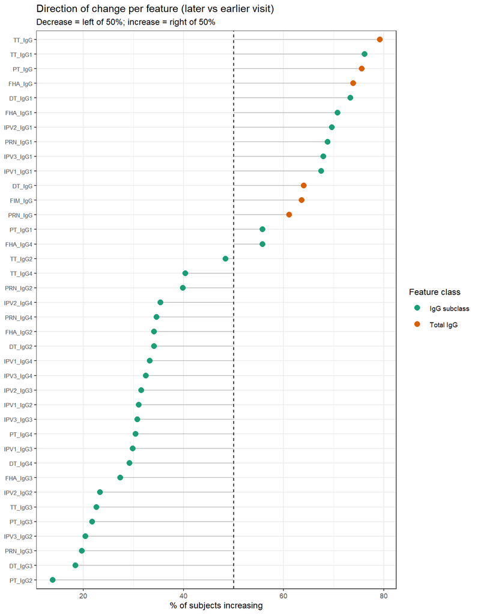

Figure 1. Percent of subjects increasing (later visit > earlier visit), by feature, coloured by feature class. Dashed line = 50% (no net direction). Features to the right increase in most subjects; features to the left decrease in most subjects.

## Figure 2 — Delta distributions by feature class

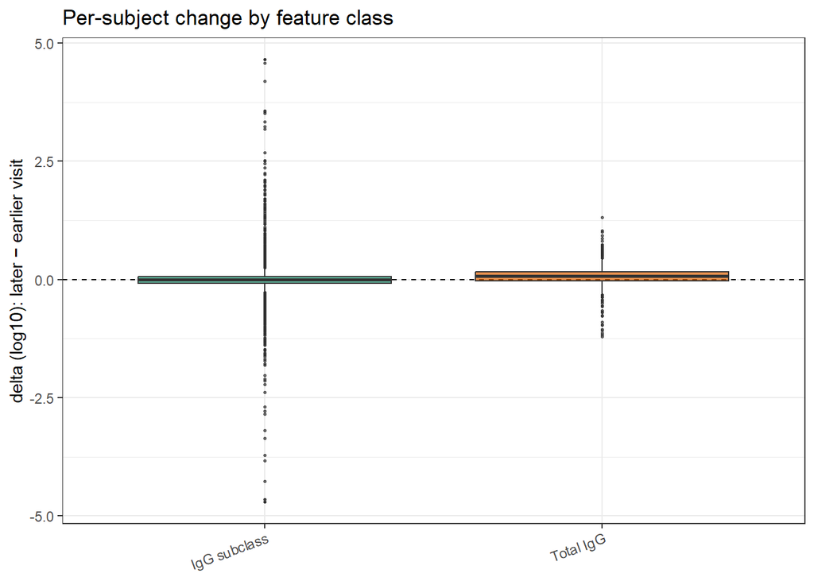

Figure 2. Distribution of per-subject delta (later − earlier visit) by feature class. Zero = no change.

## Figure 3 — Per-subject average shift

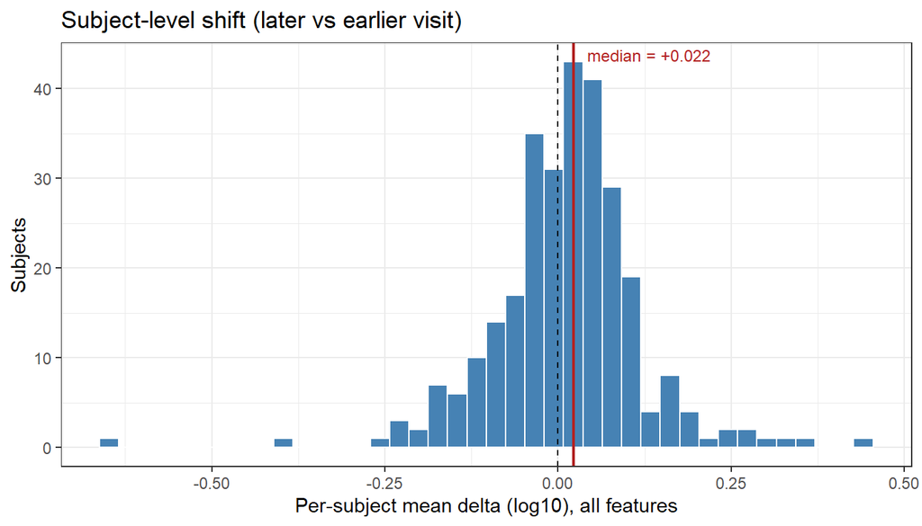

Figure 3. Per-subject mean delta across all features. A distribution clearly displaced from zero would indicate a subject-level (sample/plate) offset; a distribution straddling zero indicates feature-structured rather than uniform change.

## Figure 4 — Per-antigen histograms (analytes pooled)

Each panel pools all analytes measured for that antigen. The dashed line marks zero; the red line marks the antigen-level median delta. Antigens are ordered from the most negative (strongest decay) to the most positive (strongest increase) median.

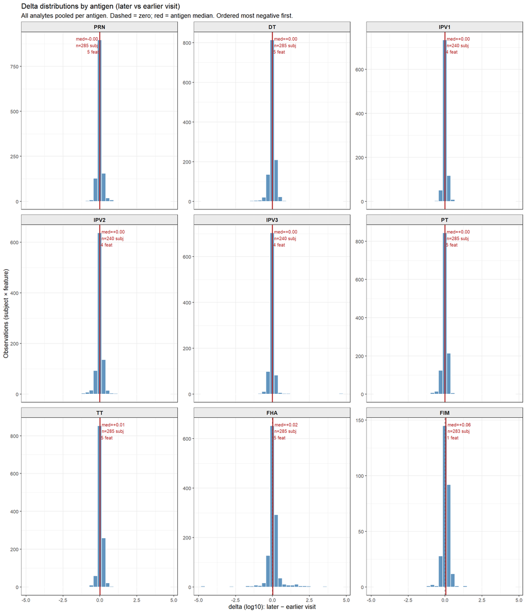

Figure 4. Per-subject delta distributions by antigen (all analytes pooled within each antigen). Dashed = zero; red = antigen median. Ordered by median delta (most negative first).

Table 6. Per-antigen summary of change (later vs earlier visit), ordered by median delta (most negative first). Each row pools all analytes available for that antigen.

| Antigen | N features | N mostly increasing | N mostly decreasing | N mixed | Median delta (log10) | Overall direction |
| --- | --- | --- | --- | --- | --- | --- |
| DT | 5 | 2 | 3 | 0 | -0.023 | predominantly decreasing |
| IPV3 | 4 | 1 | 3 | 0 | -0.018 | predominantly decreasing |
| IPV2 | 4 | 1 | 3 | 0 | -0.015 | predominantly decreasing |
| PRN | 5 | 2 | 3 | 0 | -0.005 | predominantly decreasing |
| IPV1 | 4 | 1 | 3 | 0 | -0.001 | predominantly decreasing |
| TT | 5 | 2 | 1 | 2 | -0.001 | mixed |
| PT | 5 | 1 | 3 | 1 | 0.000 | predominantly decreasing |
| FHA | 5 | 2 | 2 | 1 | 0.024 | mixed |
| FIM | 1 | 1 | 0 | 0 | 0.062 | predominantly increasing |

# Per-Analyte Histograms: Figures 5a–5f

**Note:** analytes with zero observations at one or both visits (e.g. effector-function, FcR-binding, or B-memory assays, where applicable) cannot contribute to this paired change analysis and do not appear below.

## Figure 5a — Total IgG (antigen-specific)

Total antigen-specific IgG, by antigen.

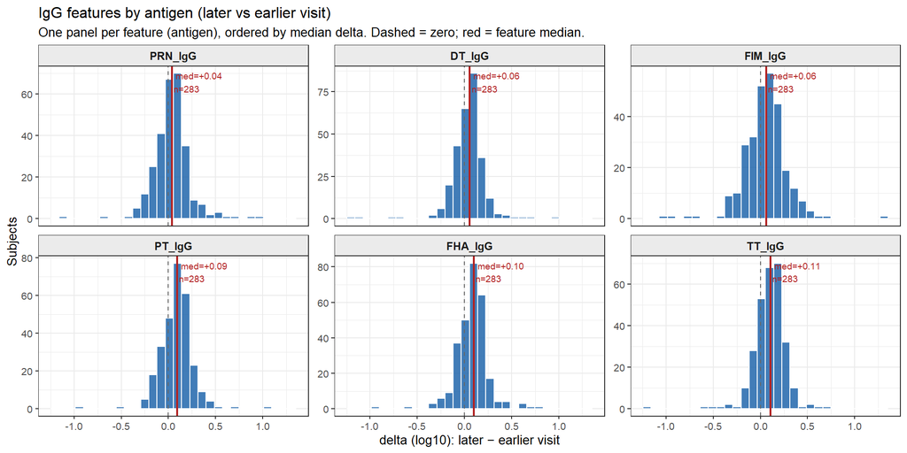

Figure 5a. Per-subject delta distributions for total antigen-specific IgG features (one panel per antigen, ordered by median delta).

## Figure 5b — IgG1

IgG1 by antigen. IgG1 is the dominant IgG subclass in serum and is efficiently transferred across the placenta.

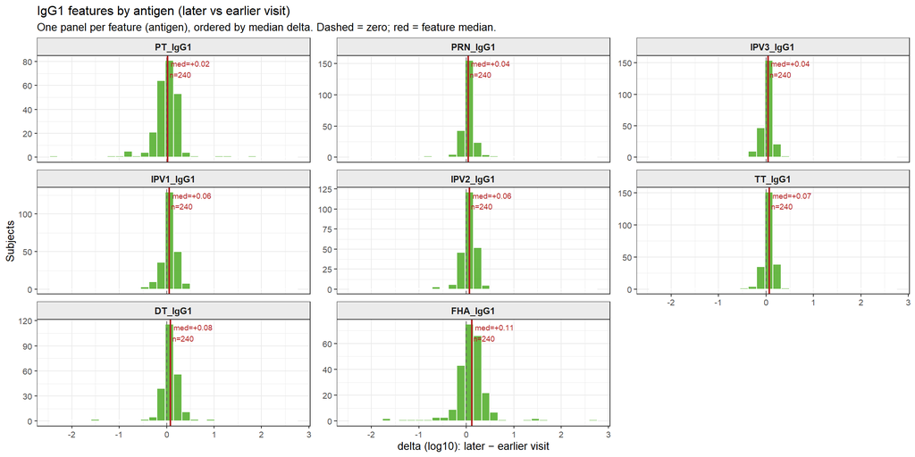

Figure 5b. Per-subject delta distributions for IgG1 features by antigen (ordered by median delta).

## Figure 5c — IgG2

IgG2 by antigen. IgG2 is enriched in responses to polysaccharide antigens and is transferred across the placenta less efficiently than IgG1.

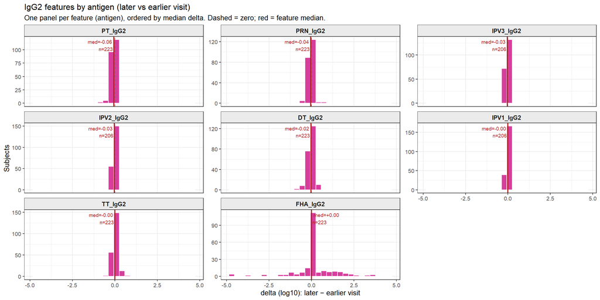

Figure 5c. Per-subject delta distributions for IgG2 features by antigen (ordered by median delta).

## Figure 5d — IgG3

IgG3 by antigen. IgG3 has the shortest serum half-life of the IgG subclasses (~7 days vs ~21 days for IgG1).

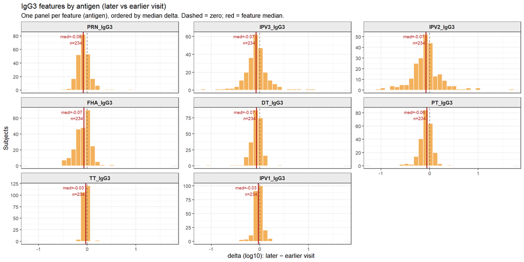

Figure 5d. Per-subject delta distributions for IgG3 features by antigen (ordered by median delta).

## Figure 5e — IgG4

IgG4 by antigen. IgG4 is typically the lowest-abundance IgG subclass and is elevated by chronic/repeated antigen exposure.

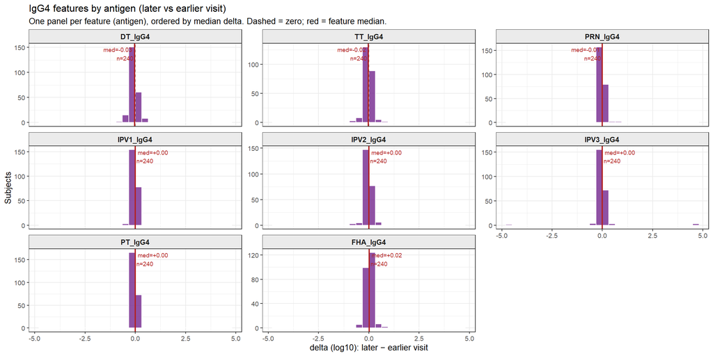

Figure 5e. Per-subject delta distributions for IgG4 features by antigen (ordered by median delta).

# Stratified by maternal arm (TdaP vs TT)

The combined (pooled) transfer results above are retained unchanged. This section ADDS the per-arm breakdown of the *same* MatBirth → CordBlood transfer (Δ = cord − maternal, log10). Because placental transfer is a property of the Fc–FcRn interaction rather than of the vaccine received, the transfer pattern is **expected to be similar across arms** — this section checks that directly.

## Direction summary by arm

Table 7. Transfer-direction summary by maternal arm (a feature is counted ‘cord > maternal’ when most paired infants exceed the mother). Similar fractions across arms support an Fc-driven transfer mechanism that is independent of the vaccine received.

| arm_name | features | % feats cord > maternal | median of feature median-deltas |
| --- | --- | --- | --- |
| TdaP | 38 | 36.8 | 0 |
| TT | 38 | 28.9 | 0 |

## Per-antigen transfer by arm (total IgG and IgG1)

Table 8. Per-antigen transplacental transfer for total IgG and IgG1, by maternal arm (six vaccine antigens, canonical order). Delta = CordBlood - MatBirth (log10); positive = cord exceeds maternal (active concentration). Similar deltas across TdaP and TT indicate transfer efficiency does not depend on the vaccine.

| Analyte | Antigen | Arm | n pairs | median MatBirth | median CordBlood | median delta (cord-mat) | % cord > maternal | p signed-rank |
| --- | --- | --- | --- | --- | --- | --- | --- | --- |
| IgG | PT | Pooled | 283 | 1.542 | 1.649 | 0.092 | 75.6 | 0.00e+00 |
| IgG | PT | TdaP | 130 | 2.110 | 2.200 | 0.122 | 77.7 | 0.00e+00 |
| IgG | PT | TT | 153 | 0.972 | 1.059 | 0.069 | 73.9 | 0.00e+00 |
| IgG | FHA | Pooled | 283 | 1.709 | 1.819 | 0.099 | 73.9 | 0.00e+00 |
| IgG | FHA | TdaP | 130 | 2.491 | 2.571 | 0.104 | 74.6 | 0.00e+00 |
| IgG | FHA | TT | 153 | 1.233 | 1.307 | 0.099 | 73.2 | 0.00e+00 |
| IgG | PRN | Pooled | 283 | 1.151 | 1.235 | 0.037 | 61.1 | 3.17e-04 |
| IgG | PRN | TdaP | 130 | 2.252 | 2.335 | 0.069 | 69.2 | 2.44e-05 |
| IgG | PRN | TT | 153 | 0.647 | 0.713 | 0.006 | 54.2 | 3.66e-01 |
| IgG | FIM | Pooled | 283 | 0.939 | 0.994 | 0.062 | 63.6 | 2.30e-06 |
| IgG | FIM | TdaP | 130 | 0.973 | 1.032 | 0.061 | 63.8 | 1.37e-03 |
| IgG | FIM | TT | 153 | 0.852 | 0.927 | 0.065 | 63.4 | 5.53e-04 |
| IgG | TT | Pooled | 283 | 0.871 | 0.986 | 0.107 | 79.2 | 0.00e+00 |
| IgG | TT | TdaP | 130 | 0.841 | 0.976 | 0.116 | 80.8 | 0.00e+00 |
| IgG | TT | TT | 153 | 0.906 | 0.990 | 0.100 | 77.8 | 0.00e+00 |
| IgG | DT | Pooled | 283 | -0.506 | -0.420 | 0.057 | 64.0 | 1.00e-07 |
| IgG | DT | TdaP | 130 | -0.181 | -0.159 | 0.074 | 68.5 | 1.20e-06 |
| IgG | DT | TT | 153 | -0.939 | -0.952 | 0.035 | 60.1 | 6.76e-03 |
| IgG1 | PT | Pooled | 240 | 2.622 | 2.615 | 0.025 | 55.8 | 2.22e-01 |
| IgG1 | PT | TdaP | 111 | 3.034 | 3.114 | 0.051 | 64.9 | 6.19e-03 |
| IgG1 | PT | TT | 129 | 2.239 | 2.234 | -0.003 | 48.1 | 3.73e-01 |
| IgG1 | FHA | Pooled | 240 | 2.980 | 2.992 | 0.113 | 70.8 | 0.00e+00 |
| IgG1 | FHA | TdaP | 111 | 3.665 | 3.809 | 0.128 | 76.6 | 4.00e-07 |
| IgG1 | FHA | TT | 129 | 2.344 | 2.490 | 0.084 | 65.9 | 9.63e-05 |
| IgG1 | PRN | Pooled | 240 | 2.107 | 2.127 | 0.037 | 68.8 | 0.00e+00 |
| IgG1 | PRN | TdaP | 111 | 2.814 | 2.868 | 0.037 | 68.5 | 1.02e-04 |
| IgG1 | PRN | TT | 129 | 1.757 | 1.809 | 0.036 | 69.0 | 1.15e-05 |
| IgG1 | TT | Pooled | 240 | 3.481 | 3.546 | 0.071 | 76.2 | 0.00e+00 |
| IgG1 | TT | TdaP | 111 | 3.462 | 3.535 | 0.104 | 81.1 | 0.00e+00 |
| IgG1 | TT | TT | 129 | 3.498 | 3.557 | 0.055 | 72.1 | 6.00e-07 |
| IgG1 | DT | Pooled | 240 | 2.724 | 2.750 | 0.081 | 73.3 | 0.00e+00 |
| IgG1 | DT | TdaP | 111 | 2.999 | 3.075 | 0.103 | 74.8 | 1.00e-06 |
| IgG1 | DT | TT | 129 | 2.148 | 2.193 | 0.071 | 72.1 | 1.00e-07 |

Close agreement between the arms is the expected result: the vaccine sets *how much* antibody the mother has to give, while the placenta transfers it by the same Fc–FcRn rules in both arms. A large arm difference would instead suggest the transfer estimate is confounded (e.g. by maternal-titre saturation or differing gestational age) and is worth checking.

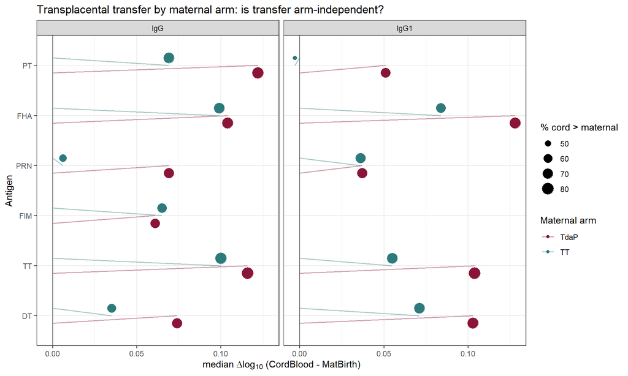

Figure A1. Transplacental transfer (median delta log10, CordBlood - MatBirth) for the six vaccine antigens, total IgG and IgG1, by maternal arm. Point size = percent of infants with cord > maternal. Positive = cord exceeds maternal. Overlapping TdaP/TT points indicate arm-independent transfer.

# Interpretation

*All quantities in this section are computed from the current data at knit time (from `feat_summary`, `analyte_sum`, `xfer_all` and the headline diagnostics). Nothing is hardcoded, so the narrative always matches the tables and figures above.*

This comparison measures **transplacental transfer**: cord blood (`CordBlood`) versus the mother at delivery (`MatBirth`), with Δ = cord − maternal (log10). Selective, FcRn-mediated transfer predicts a split **by IgG subclass rather than by antigen**, with the best-transferred subclass concentrated above maternal levels and the others arriving at or below.

## Overview

Across the **38** well-covered features, **13** transfer above maternal (cord > maternal), **21** below, and **4** are mixed. The pooled median Δ is **+0.000** log10 — near zero because the subclasses that concentrate above maternal and those that fall below offset — while **58.2%** of paired infants are net positive (the best-transferred compartment is the largest).

The split is **by subclass, not by antigen**: analytes transferred above maternal are IgG1, IgG; below maternal, IgG3, IgG2, IgG4. A transfer mechanism acts on the Fc region (subclass), not on antigen specificity, so consistent direction within each subclass across antigens is exactly what selective FcRn transfer predicts.

## What the data show, by analyte

- **IgG1** — best-transferred features: FHA (+0.11, 71% cord>mat); DT (+0.08, 73% cord>mat); TT (+0.07, 76% cord>mat); IPV2 (+0.06, 70% cord>mat).
- **Total IgG** — tracks IgG1; top: TT (+0.11, 79% cord>mat); FHA (+0.10, 74% cord>mat); PT (+0.09, 76% cord>mat); FIM (+0.06, 64% cord>mat).
- **IgG3** — most depleted (cord < maternal): PRN (-0.08, 20% cord>mat); IPV3 (-0.07, 31% cord>mat); IPV2 (-0.07, 32% cord>mat); FHA (-0.07, 27% cord>mat).
- **IgG2** — most depleted: PT (-0.06, 14% cord>mat); PRN (-0.04, 40% cord>mat); IPV3 (-0.04, 20% cord>mat); IPV2 (-0.03, 23% cord>mat).
- **IgG4** — most depleted: DT (-0.03, 29% cord>mat); TT (-0.02, 40% cord>mat); PRN (-0.00, 35% cord>mat).

FcRn binds and actively concentrates the best-transferred IgG subclass in the fetal circulation so cord titres can exceed maternal, while the less efficiently transferred subclasses arrive at or below maternal levels — the canonical placental-transfer hierarchy.

## Focus: *Bordetella pertussis* antigens

Transfer of the pertussis antigens present in the data (the compartment maternal vaccination amplifies):

- **PT** — total IgG +0.09 (76% cord>mat); IgG1 +0.02 (56% cord>mat)
- **FHA** — total IgG +0.10 (74% cord>mat); IgG1 +0.11 (71% cord>mat)
- **PRN** — total IgG +0.04 (61% cord>mat); IgG1 +0.04 (69% cord>mat)
- **FIM** — total IgG +0.06 (64% cord>mat)

Because IgG1 is preferentially transferred, the antibody the infant receives is **enriched for IgG1** relative to the maternal mixture. The IgG1 anti-pertussis antibody the mother amplified by vaccination (companion `PregEarly -> MatBirth` analysis) is therefore the compartment the placenta delivers best — the mechanistic payoff of maternal vaccination for the newborn.

## By maternal arm

Fraction of features with cord > maternal, by arm: **TdaP 36.8%** vs **TT 28.9%** (Table 7). Typical per-antigen transfer Δ: total IgG (TdaP +0.089, TT +0.067); IgG1 (TdaP +0.103, TT +0.055).

The two arms are **closely matched**: the larger of the total-IgG and IgG1 transfer-Δ gaps between TdaP and TT is 0.048 log10 (about 1.12-fold). That is the expected signature of an Fc–FcRn transfer mechanism that does not depend on the vaccine received: the vaccine sets *how much* anti-pertussis IgG1 the mother has to give, and the placenta transfers it by the same rules in both arms.

In contrast to the strongly arm-dependent `PregEarly -> MatBirth` vaccination step, transfer is governed by the Fc–FcRn interaction rather than by which vaccine the mother received; the per-arm tables and Figure A1 above let you confirm the subclass hierarchy holds the same way in both arms.

## Scale and comparability

Both `MatBirth` and `CordBlood` subclass values are normalized bead-array values on a common scale, and total IgG comes from a separate ELISA path. Agreement between the total-IgG and IgG1 transfer signals, together with a clean subclass ordering, argues the pattern is biological rather than a scaling artifact. Note that any feature measured at only one of the two visits (e.g. a whole-cell readout present at cord but not at maternal birth) contributes no paired data and does not enter this comparison (see Table 1).

## What would confirm or refine this interpretation

- **Compute explicit cord:maternal ratios per subclass** and compare against published transfer ratios; the Δ values here are log10 differences and should line up with that literature.
- **Relate transfer efficiency to gestational age at birth and to maternal titre.** Transfer rises with gestational age and can saturate at very high maternal titres; both modulate the cord:maternal ratio, especially for the boosted pertussis IgG1.
- **Read Tables 7–8 and Figure A1** to confirm the transfer hierarchy is the same in both arms, rather than relying on the pooled medians alone.

# Participant Accounting

Table 9. Per-feature paired availability (n MatBirth / n CordBlood / n used).

| Section | Stratum | Model | N entered | N used | N dropped | Dropped due to (NA driver) |
| --- | --- | --- | --- | --- | --- | --- |
| Coverage | DT_IgG | paired availability | 287 | 283 | 4 | MatBirth n=283, CordBlood n=287 |
| Coverage | FHA_IgG | paired availability | 287 | 283 | 4 | MatBirth n=283, CordBlood n=287 |
| Coverage | FIM_IgG | paired availability | 287 | 283 | 4 | MatBirth n=283, CordBlood n=287 |
| Coverage | PRN_IgG | paired availability | 287 | 283 | 4 | MatBirth n=283, CordBlood n=287 |
| Coverage | PT_IgG | paired availability | 287 | 283 | 4 | MatBirth n=283, CordBlood n=287 |
| Coverage | TT_IgG | paired availability | 287 | 283 | 4 | MatBirth n=283, CordBlood n=287 |
| Coverage | DT_IgG1 | paired availability | 247 | 240 | 7 | MatBirth n=247, CordBlood n=242 |
| Coverage | DT_IgG4 | paired availability | 247 | 240 | 7 | MatBirth n=247, CordBlood n=242 |
| Coverage | FHA_IgG1 | paired availability | 247 | 240 | 7 | MatBirth n=247, CordBlood n=242 |
| Coverage | FHA_IgG4 | paired availability | 247 | 240 | 7 | MatBirth n=247, CordBlood n=242 |
| Coverage | IPV1_IgG1 | paired availability | 247 | 240 | 7 | MatBirth n=247, CordBlood n=242 |
| Coverage | IPV1_IgG4 | paired availability | 247 | 240 | 7 | MatBirth n=247, CordBlood n=242 |
| Coverage | IPV2_IgG1 | paired availability | 247 | 240 | 7 | MatBirth n=247, CordBlood n=242 |
| Coverage | IPV2_IgG4 | paired availability | 247 | 240 | 7 | MatBirth n=247, CordBlood n=242 |
| Coverage | IPV3_IgG1 | paired availability | 247 | 240 | 7 | MatBirth n=247, CordBlood n=242 |
| Coverage | IPV3_IgG4 | paired availability | 247 | 240 | 7 | MatBirth n=247, CordBlood n=242 |
| Coverage | PRN_IgG1 | paired availability | 247 | 240 | 7 | MatBirth n=247, CordBlood n=242 |
| Coverage | PRN_IgG4 | paired availability | 247 | 240 | 7 | MatBirth n=247, CordBlood n=242 |
| Coverage | PT_IgG1 | paired availability | 247 | 240 | 7 | MatBirth n=247, CordBlood n=242 |
| Coverage | PT_IgG4 | paired availability | 247 | 240 | 7 | MatBirth n=247, CordBlood n=242 |
| Coverage | TT_IgG1 | paired availability | 247 | 240 | 7 | MatBirth n=247, CordBlood n=242 |
| Coverage | TT_IgG4 | paired availability | 247 | 240 | 7 | MatBirth n=247, CordBlood n=242 |
| Coverage | DT_IgG3 | paired availability | 241 | 234 | 7 | MatBirth n=241, CordBlood n=236 |
| Coverage | FHA_IgG3 | paired availability | 241 | 234 | 7 | MatBirth n=241, CordBlood n=236 |
| Coverage | IPV1_IgG3 | paired availability | 241 | 234 | 7 | MatBirth n=241, CordBlood n=236 |
| Coverage | IPV2_IgG3 | paired availability | 241 | 234 | 7 | MatBirth n=241, CordBlood n=236 |
| Coverage | IPV3_IgG3 | paired availability | 241 | 234 | 7 | MatBirth n=241, CordBlood n=236 |
| Coverage | PRN_IgG3 | paired availability | 241 | 234 | 7 | MatBirth n=241, CordBlood n=236 |
| Coverage | PT_IgG3 | paired availability | 241 | 234 | 7 | MatBirth n=241, CordBlood n=236 |
| Coverage | TT_IgG3 | paired availability | 241 | 234 | 7 | MatBirth n=241, CordBlood n=236 |
| Coverage | DT_IgG2 | paired availability | 235 | 223 | 12 | MatBirth n=235, CordBlood n=225 |
| Coverage | FHA_IgG2 | paired availability | 235 | 223 | 12 | MatBirth n=235, CordBlood n=225 |
| Coverage | PRN_IgG2 | paired availability | 235 | 223 | 12 | MatBirth n=235, CordBlood n=225 |
| Coverage | PT_IgG2 | paired availability | 235 | 223 | 12 | MatBirth n=235, CordBlood n=225 |
| Coverage | TT_IgG2 | paired availability | 235 | 223 | 12 | MatBirth n=235, CordBlood n=225 |
| Coverage | IPV1_IgG2 | paired availability | 217 | 206 | 11 | MatBirth n=217, CordBlood n=208 |
| Coverage | IPV2_IgG2 | paired availability | 217 | 206 | 11 | MatBirth n=217, CordBlood n=208 |
| Coverage | IPV3_IgG2 | paired availability | 217 | 206 | 11 | MatBirth n=217, CordBlood n=208 |
| Coverage | WHOLE_WT_IgG | paired availability | 209 | 0 | 209 | MatBirth n=0, CordBlood n=209 |

*Reuses the shared pipeline (`config/endpoints.R`, `R/serology_helpers.R`, the global visit recode, and the N-tracker). Knit both formats with* `rmarkdown::render("cord_to_infmon2_analysis_refactored.Rmd", output_format = "all")`.